# Delayed Flight Site

ML

Python

Author

Yuki Yu

Published

March 22, 2024

# Delayed Flight Site

### GitHub Repo:

https://github.com/trentbellinger/PIC-16B-Project.git

## Overview

The Delayed Flight Site is a web-based application designed to predict flight departure delays within the United States. It aims to assist frequent flyers in efficiently organizing their flight schedules and travel plans by allowing them to anticipate and plan for potential delays.

## Objective

Our objective was to use predictive analytics to enhance travel planning. Using historical flight data, our platform gives travelers insight to potential delays on their upcoming flights, minimizing the inconvenience of delays. The ultimate goal is to transform how travelers approach flying, shifting from reactive to proactive planning.

## Features

1. Itinerary to Save User-Inputted Flights
2. Flight Delay Predictions Based on User input
3. Interactive Visualizations for Additional Insight

## 1. Data Acquisition and SQL Database Creation

We started by importing flights data from the US Bureau of Transportation. This data was obtained through the following link:  
https://www.transtats.bts.gov/DL_SelectFields.aspx?gnoyr_VQ=FGK&QO_fu146_anzr=b0-gvzr

[figure not shown]

```python
import pandas as pd
import os

os.chdir('/content/drive/MyDrive/PIC16B_Datasets')

nov22 = pd.read_csv("nov22.csv")
dec22 = pd.read_csv("dec22.csv")
jan23 = pd.read_csv("jan23.csv")
feb23 = pd.read_csv("feb23.csv")
mar23 = pd.read_csv("mar23.csv")
apr23 = pd.read_csv("apr23.csv")
may23 = pd.read_csv("may23.csv")
jun23 = pd.read_csv("jun23.csv")
jul23 = pd.read_csv("jul23.csv")
aug23 = pd.read_csv("aug23.csv")
sep23 = pd.read_csv("sep23.csv")
oct23 = pd.read_csv("oct23.csv")
nov23 = pd.read_csv("nov23.csv")
all_data = pd.concat([nov22, dec22, jan23, feb23, mar23, apr23, may23, jun23, jul23, aug23, sep23, oct23, nov23],
                     ignore_index = True, axis = 0)
all_data.shape
```

```
DtypeWarning: Columns (39) have mixed types. Specify dtype option on import or set low_memory=False.
  jan23 = pd.read_csv("jan23.csv")
```

```
(7818349, 50)
```

After getting data about each flight, we also wanted to get longitude and latitude data for each airport to be able to eaily plot our observations. This was done through an API called `airportsdata`. We will create a pandas dataframe using the airports data that contains the longitude and latitude of every airport in the United States. This process is outlined below.

```python
!pip install -U airportsdata
import airportsdata
airports = airportsdata.load('IATA')  # key is the ICAO identifier (the default)
airports_df = pd.DataFrame([(airport, dic["lat"], dic["lon"]) for airport, dic in airports.items()])
airports_df.rename(columns = {0:"AIRPORT_ID", 1:"LATITUDE", 2:"LONGITUDE"}, inplace = True)
airports_df.head()
```

|  | AIRPORT_ID | LATITUDE | LONGITUDE |
| --- | --- | --- | --- |
| 0 | OCA | 25.324317 | -80.275729 |
| 1 | CYT | 60.080849 | -142.495494 |
| 2 | FWL | 62.509183 | -153.890626 |
| 3 | CSE | 38.851937 | -106.932821 |
| 4 | CUS | 31.823711 | -107.626967 |

Now that we have two large datasets, we will create a SQL database to store the data. The creation of a SQL database will allow us to easily look at subsets of the data without having to load in the whole dataframe. This will significantly speed up the data loading for the rest of our project. We will use this SQL database in every aspect of our project from now on. This SQL database is created below.

```python
import sqlite3

conn = sqlite3.connect("flights.db")

all_data.to_sql("flights", conn, if_exists = "replace", index = False)
airports_df.to_sql("airports", conn, if_exists = "replace", index = False)

conn.close()
```

```python
with sqlite3.connect("flights.db") as conn:
    cmd = \
    f"""
    SELECT
        ORIGIN, DEST, OP_CARRIER_FL_NUM, DEP_DELAY
    FROM
        flights
    WHERE
        YEAR = "2022"
        AND
        MONTH = 11
        AND
        DAY_OF_MONTH = 1
        AND
        OP_UNIQUE_CARRIER = "9E"
        AND
        DEP_DEL15 = 1
    """
    df_test = pd.read_sql_query(cmd, conn)

print(df_test.shape)
df_test.head()
```

```
(31, 4)
```

|  | ORIGIN | DEST | OP_CARRIER_FL_NUM | DEP_DELAY |
| --- | --- | --- | --- | --- |
| 0 | LGA | CVG | 4635 | 22.0 |
| 1 | CAE | ATL | 4675 | 22.0 |
| 2 | IND | JFK | 4694 | 20.0 |
| 3 | BNA | LGA | 4737 | 105.0 |
| 4 | LGA | MCI | 4743 | 146.0 |

We will not preform a small test to make sure the table is functional in our database. We will output a dataframe of the airport id, latitude, and longitude of all airports lower than -100 longitude.

```python
with sqlite3.connect("flights.db") as conn:
    cmd = \
    """
    SELECT
        AIRPORT_ID, LATITUDE, LONGITUDE
    FROM
        airports
    WHERE
        LONGITUDE < -100
    """
    df_airports_test = pd.read_sql_query(cmd, conn)

print(df_airports_test.shape)
df_airports_test.head()
```

```
(1114, 3)
```

|  | AIRPORT_ID | LATITUDE | LONGITUDE |
| --- | --- | --- | --- |
| 0 | CYT | 60.080849 | -142.495494 |
| 1 | FWL | 62.509183 | -153.890626 |
| 2 | CSE | 38.851937 | -106.932821 |
| 3 | CUS | 31.823711 | -107.626967 |
| 4 | ICY | 59.969019 | -141.661770 |

We can see that the database works as intended. This database will be very important for our project because it will allow us to quickly subset our dataset that contains about 8 million observations. The general structure of the database is displayed in the visualization below.

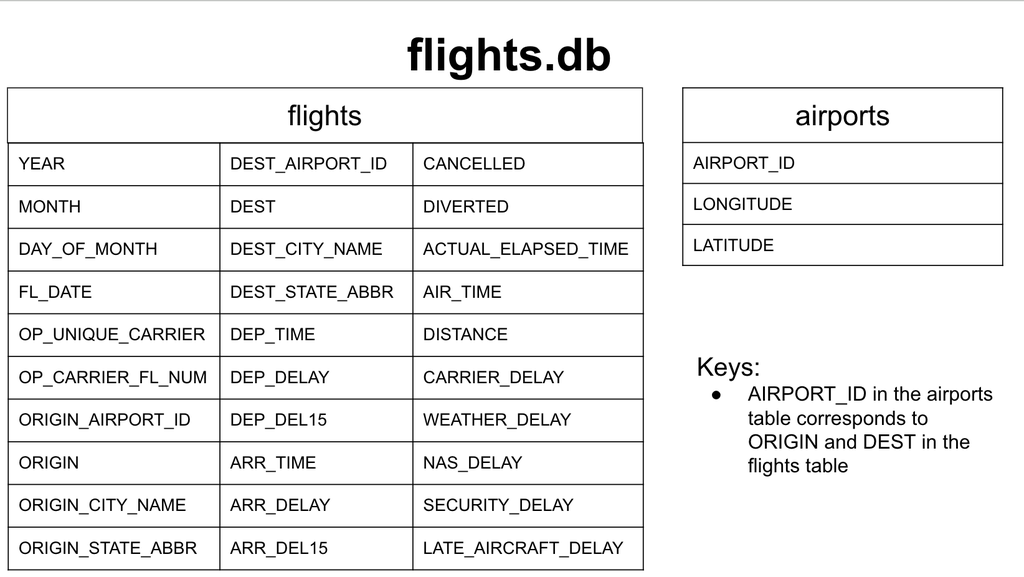

sql_db.png

## 2. Data Preprocessing and Building a Model

```python
def get_flight_model_data():
    '''
    Returns a pandas dataframe of all the necessary predictors to predict flight delay.
    (note: must have the flights.db database)
    Args:
        none
    Returns:
        a pandas dataframe with all necessary predictors
    '''
    with sqlite3.connect("flights.db") as conn:
        cmd = \
        """
        SELECT
            flights.YEAR, flights.MONTH, flights.DAY_OF_MONTH, flights.DEP_TIME, flights.ARR_TIME,
            flights.OP_UNIQUE_CARRIER, flights.ORIGIN, flights.DEST, flights.DISTANCE, flights.DEP_DEL15,
            airports.LATITUDE "ORIGIN_LATITUDE", airports.LONGITUDE "ORIGIN_LONGITUDE"
        FROM
            flights
        INNER JOIN
            airports ON flights.ORIGIN = airports.AIRPORT_ID
        """
        df = pd.read_sql_query(cmd, conn)
    with sqlite3.connect("flights.db") as conn:
        cmd = \
        """
        SELECT
            flights.DEST, airports.LATITUDE "DEST_LATITUDE", airports.LONGITUDE "DEST_LONGITUDE"
        FROM
            flights
        INNER JOIN
            airports ON flights.DEST = airports.AIRPORT_ID
        """
        df_dest = pd.read_sql_query(cmd, conn)
    df["DEST_LATITUDE"] = df_dest["DEST_LATITUDE"]
    df["DEST_LONGITUDE"] = df_dest["DEST_LONGITUDE"]
    return df

df = get_flight_model_data()
print(df.shape)
df.head()
```

```
(7818349, 14)
```

|  | YEAR | MONTH | DAY_OF_MONTH | DEP_TIME | ARR_TIME | OP_UNIQUE_CARRIER | ORIGIN | DEST | DISTANCE | DEP_DEL15 | ORIGIN_LATITUDE | ORIGIN_LONGITUDE | DEST_LATITUDE | DEST_LONGITUDE |
| --- | --- | --- | --- | --- | --- | --- | --- | --- | --- | --- | --- | --- | --- | --- |
| 0 | 2022 | 11 | 1 | 1355.0 | 1747.0 | 9E | XNA | LGA | 1147.0 | 0.0 | 36.281579 | -94.307766 | 40.777250 | -73.872611 |
| 1 | 2022 | 11 | 1 | 1412.0 | 1609.0 | 9E | LGA | CVG | 585.0 | 1.0 | 40.777250 | -73.872611 | 39.048837 | -84.667821 |
| 2 | 2022 | 11 | 1 | 1345.0 | 1550.0 | 9E | LGA | XNA | 1147.0 | 0.0 | 40.777250 | -73.872611 | 36.281579 | -94.307766 |
| 3 | 2022 | 11 | 1 | 1550.0 | 1648.0 | 9E | LSE | MSP | 119.0 | 0.0 | 43.879266 | -91.256634 | 44.881972 | -93.221778 |
| 4 | 2022 | 11 | 1 | 1418.0 | 1506.0 | 9E | MSP | LSE | 119.0 | 0.0 | 44.881972 | -93.221778 | 43.879266 | -91.256634 |

## 4. Adding Interactive Visualizations with Plotly Dash

This Plotly Dash app is an interactive tool designed to give users insights into flight delays and travel patterns across U.S. airports.

For faster processing time, we decided to process the data first and writing them out to separate CSV files that were suited for each visualization instead of processing the data within our Dash app.

The app’s layout includes a markdown block at the top that explains the functionalities and how to use the app. A `RadioItems` selection lets users choose between the flight routes, heatmap, or rush hour visualizations, dynamically updating the display content based on their choice.

Callbacks are set up to respond to user interactions, such as entering airport codes and clicking the “Plot Routes” button, which generates the visualizations accordingly. For the heatmap and rush hour charts, the app processes flight count and delay data, providing a detailed analysis of travel patterns for better planning and decision-making. The app is equipped to handle data transformations and plotting, making it a comprehensive tool for travelers looking to optimize their itineraries.

### **Here is a more detailed look at each visualization**

### **Flight Routes Visualization:**

This app allows you to visualize flight routes between airports and the average proportion of delays. Enter the airport codes for departures and arrivals, and press “Plot Routes” to see the routes on the map.

Each number in the legend is a group number that represents the proportion of delayed flights on average for each route.

Here is what each number in the legend means:

```
    - 0: delay proportion <= 0.1
    - 1: 0.1 < delay proportion <= 0.15
    - 2: 0.15 < delay proportion <= 0.2
    - 3: 0.2 < delay proportion <= 0.25
    - 4: 0.25 < delay proportion <= 0.3
    - 5: delay proportion > 0.3
```

```python
# @title Flight Routes Visualization
from IPython.display import Image, display

# Correct path with no spaces in folder names
image_path = '/content/drive/MyDrive/PIC16B_Datasets/routes.png'

# Display the image
display(Image(filename=image_path))
```

[figure not shown]

**Callback: `update_map`**

This callback listens for user interaction with the ‘Plot Routes’ button or changes in the visualization mode selector. Upon activation, it processes user input to plot flight routes between selected departure and arrival airports. The callback assembles a list of route data based on the input fields for up to 10 routes.

```python
# Callback to update the map based on the inputs
@app.callback(
    #Output('content-route', 'children'),
    Output('map', 'figure'),
    [Input('vis-mode-selector', 'value'),
     Input('plot-button', 'n_clicks')
    ],
    [State({'type': 'departure-input', 'index': ALL}, 'value'),
     State({'type': 'arrival-input', 'index': ALL}, 'value'),
    ]
)
```

**Function: `update_map`**

This function is the core of the `update_map` callback. It transforms user input into uppercase to match the database format, constructs a key for each route combining departure and arrival airport codes, and retrieves relevant data like group classification, flight count, and delay proportion. It then checks for the existence of coordinates for the given airports and, if found, prepares a structured dictionary of route information to be plotted.

```python
def update_map(n_clicks, vis_mode, departures, arrivals):
    """
    Responds to user inputs to generate and update a flight route map.

    Parameters:
    - n_clicks (int): Number of times the plot button has been clicked.
    - vis_mode (str): The visualization mode selected by the user.
    - departures (list): List of user-input departure airport codes.
    - arrivals (list): List of user-input arrival airport codes.

    Returns:
    - Plotly Figure: A figure object that contains the updated flight routes map.
    """
    routes = []

    departures = [dep.upper() for dep in departures if dep is not None]
    arrivals = [arr.upper() for arr in arrivals if arr is not None]

    # loop through each pair of depature and arrival inputs
    for dep, arr in zip(departures, arrivals):
        if dep and arr:  # Ensure both inputs are provided
            # Generate the composite key for the current route
            route_key = f"{dep}_{arr}"
            # Look up the group for the current route
            group = route_dict.get(route_key)
            count = count_dict.get(route_key)
            delay_proportion = dep_del_dict.get(route_key)
            dep_coords = airport_coordinates.get(dep)
            arr_coords = airport_coordinates.get(arr)

            # Proceed only if coordinates for both airports are found
            if dep_coords and arr_coords:
                # Construct the route data structure
                route = {
                    "departure_airport": dep,
                    "arrival_airport": arr,
                    "departure_lat": dep_coords['lat'],
                    "departure_lon": dep_coords['lon'],
                    "arrival_lat": arr_coords['lat'],
                    "arrival_lon": arr_coords['lon'],
                    "delay_proportion": delay_proportion,
                    "group": group,
                    "flight_count": count
                }
                routes.append(route)

    fig = create_figure_with_routes(routes)

    return fig
```

**Function: `create_figure_with_routes`**

This function takes the list of routes created by `update_map` and visualizes them on a map. Each route is represented as a line between its departure and arrival coordinates with markers at each airport. The lines and markers are color-coded by delay proportion group. The function sets up the map’s appearance, including its geographic projection (set to the United States) and styling details. The resulting figure is then returned to the update_map callback to update the ‘map’ component in the app’s layout.

```python
def create_figure_with_routes(routes):
    """
    Creates a Plotly map visualization for the given flight routes.

    Parameters:
    - routes (list): A list of dictionaries, each containing data for a flight route.

    Returns:
    - Plotly Figure: A figure object that visualizes the flight routes on a map.
    """
    fig = go.Figure()
    # Define a color scheme for the different groups
    group_colors = {
        0: "#1f77b4",  # Muted blue
        1: "#ff7f0e",  # Safety orange
        2: "#2ca02c",  # Cooked asparagus green
        3: "#d62728",  # Brick red
        4: "#9467bd",  # Muted purple
        5: "#8c564b",  # Chestnut brown
    }
    # Loop through each route and add it to the figure with the respective color
    for route in routes:
        # Get the color for the current group or default to black if not found
        route_color = group_colors.get(route["group"])

        fig.add_trace(
            go.Scattergeo(
                lon = [route["departure_lon"], route["arrival_lon"]],
                lat = [route["departure_lat"], route["arrival_lat"]],
                text = [f"{route['departure_airport']}", f"{route['arrival_airport']}"],
                hoverinfo='text',
                mode = "lines+markers",
                line = dict(width = 2, color = route_color),
                marker = dict(size = 4, color = route_color),
                name = route["group"],
            )
        )
        # Update layout of the map
    fig.update_layout(
        title_text = "Flight Routes and Delay Proportions",
        showlegend = True,
        geo = dict(
            projection_type = "albers usa",
            showland = True,
            landcolor = "rgb(200, 200, 200)",
            countrycolor = "rgb(204, 204, 204)",
            showsubunits=True,  # Show state lines and other subunits
            subunitwidth=1  # Width of the subunit lines (state lines)
        ),
    )
    return fig
```

### **Heatmap Visualization:**

The heatmap illustrates U.S. airport departures, highlighting flight volume and delay frequency.

```python
# @title Heatmap

# Correct path with no spaces in folder names
image_path1 = '/content/drive/MyDrive/PIC16B_Datasets/heatmap.png'

# Display the image
display(Image(filename=image_path1))
```

[figure not shown]

**Callback: create_composite_map**

This callback updates the content of the ‘content-heatmap’ division based on the visualization mode selected by the user. When the ‘Heatmap’ mode is selected, it triggers the create_composite_map function to generate and display a heatmap.

```python
@app.callback(
    Output('content-heatmap', 'children'),
    Input('vis-mode-selector', 'value')
)
```

**Function: create_composite_map**

The create_composite_map function constructs a heatmap visualization of U.S. flight departures. It uses the `Scattergeo` trace of Plotly to plot the longitude and latitude of origin airports as points on a map.

Each point’s size represents the delay proportion, offering a visual representation of the flight volume and delay frequency. The color intensity corresponds to higher delay percentages.

The hovertemplate enriches the points with interactive data display on hover, showing the flight count and delay proportion for each airport. The function returns a Plotly figure object configured with a title and a stylized geographical layout, ready to be rendered in the app.

```python
def create_composite_map():
    """
    Generates a heatmap Plotly figure displaying U.S. airport flight delays.

    Size of points reflects flight count; color indicates delay proportions.

    Returns:
    - Plotly Figure: A map with scaled markers for visualizing flight delays.
    """

    fig = go.Figure(data=go.Scattergeo(
        lon = dep_delay['ORIGIN_LONGITUDE'],
        lat = dep_delay['ORIGIN_LATITUDE'],
        text = dep_delay['ORIGIN'],
        customdata = dep_delay[['flight_count', 'DEP_DEL15']],  # Add flight count and delay proportions to the custom data
        hovertemplate = (
            "<b>%{text}</b><br>"
            "Flight Count: %{customdata[0]}<br>"
            "Delay Proportion: %{customdata[1]:.2f}<extra></extra>"  # Format delay proportion to show two decimal places
        ),
        marker = dict(
            size = dep_delay['DEP_DEL15'] * 50,  # Scale the points based on delay proportion
            color = dep_delay['DEP_DEL15'],
            colorscale = 'Viridis',
            showscale = True,
            colorbar_title = 'Delay Proportion'
        )
    ))

    fig.update_layout(
        title = 'Heatmap of Flight Delay Proportions',
        geo = dict(
            scope = 'usa',
            projection_type = 'albers usa',
            showland = True,
            landcolor = 'rgb(217, 217, 217)',
            subunitcolor = "rgb(255, 255, 255)"
        )
    )



    return fig
```

### **Rush Hour:**

This app offers insights into the frequency and peak hours of flight departures from specific airports.

By inputting an airport code and a flight’s departure time, users can generate a bar chart that reveals the airport’s busiest periods, aiding in understanding rush hour trends.

```python
# @title Rush Hour
from IPython.display import Image, display

# Correct path with no spaces in folder names
image_path2 = '/content/drive/MyDrive/PIC16B_Datasets/rush_hour.png'

# Display the image
display(Image(filename=image_path2))
```

[figure not shown]

**Callback: update_hourly_activity**

This callback updates the histogram visualization for hourly flight activity based on user interaction. It triggers when the user selects a visualization mode and clicks the ‘Update’ button. The callback receives the airport code and hour input by the user and passes this information to the `update_hourly_activity` function to refresh the histogram display.

```python
@app.callback(
    Output('hist', 'figure'),
    [Input('vis-mode-selector', 'value'),
     Input('update-button', 'n_clicks')],
    [State('origin-input', 'value'), State('hour-input', 'value')]
)
```

**Function: `update_hourly_activity`**

This function creates a histogram to display the number of flights for each hour from a specified airport. It takes user inputs for the airport and hour, converts the airport code to uppercase, filters the dataset for the selected airport, and constructs a bar chart. If an hour is provided, it highlights that hour on the chart. The function returns a Plotly figure object with the updated histogram for rendering in the app.

```python
def update_hourly_activity(n_clicks, vis_mode, selected_origin, selected_hour):
    """
    Generates a histogram figure of flight counts for each hour of the day based on user-selected origin and hour.

    This function filters the data for the specified airport origin and hour, then produces a bar plot showing the
    number of flights departing at each hour of the day. If an hour is selected, it highlights that hour on the histogram.

    Parameters:
    - n_clicks (int): Number of clicks received. This parameter can be used to trigger the function in a callback.
    - vis_mode (str): The visualization mode. Currently unused in the function but can be utilized for future modes.
    - selected_origin (str): The airport origin code selected by the user.
    - selected_hour (int/str): The hour selected by the user for highlighting in the histogram.

    Returns:
    - fig (plotly.graph_objs._figure.Figure): A Plotly figure object containing the histogram of hourly flight activity.
    """

    if selected_origin is not None:
        selected_origin = selected_origin.upper()

    # Otherwise, generate the histogram for the selected origin and hour
    filtered_df = dep_count[dep_count['ORIGIN'] == selected_origin]

    # Create a barplot of flights by hour
    # First, we create the text that will be displayed on each bar
    filtered_df['text'] = 'Airport: ' + filtered_df['ORIGIN'] \
                      + '<br>Hour: ' + filtered_df['dep_hour'].astype(str) \
                      + '<br>Flights: ' + filtered_df['dep_count'].astype(str)

    # Now we can create the bar plot
    fig = px.bar(filtered_df, x='dep_hour', y='dep_count', title='Hourly Flight Activity')

    fig.update_layout(xaxis_title='Departure Hour', yaxis_title='Numer of Flights')
    # To add hover text, you can use the hover_data parameter
    fig.update_traces(hovertemplate=filtered_df['text'])

    # Highlight the selected hour if one is selected

    try:
        selected_hour = int(selected_hour)
        if 0 <= selected_hour <= 23:
            fig.add_vline(x=selected_hour, line_color="red", annotation_text="Selected Hour")
    except (ValueError, TypeError):
        pass

    return fig
```

## 6. Conclusions

In conclusion, we created a Flask web app that helps users predict whether or not their flight will be delayed. Our project aims to predict flight delays, offering substantial benefits to travelers and airports by providing more accurate departure times and enhancing planning efficiency. However, it faces challenges such as data quality and availability, computational limitations, and the complexity of developing predictive models. Mitigating these risks requires thorough data assessment, scalable processing solutions, and flexible project scope management. Ethically, while the project presents an opportunity to improve the travel experience for passengers and operational efficiency for airports, it may also highlight airlines’ operational shortcomings, potentially impacting their reputation. Despite these considerations, the project stands to make a positive impact by enabling better-informed travel decisions and streamlining airport traffic management, contributing to a more predictable and less stressful travel experience for all involved.